# ACTG175 Binary Harm Search: Simulation Study

# 3 Single Trial Sanity Check

**Single simulated trial + FS analysis alt (click to expand)**

```r
df_sim <- simulate_from_glm_dgm(dgm_calibrated, n = sim_n, seed = 42)
```

**Single simulated trial + FS analysis alt (click to expand)**

```r
itt_fit <- glm(y_sim ~ treat_sim, family = "binomial", data = df_sim)
itt_OR <- exp(coef(itt_fit)["treat_sim"])
itt_event <- with(df_sim,mean(y_sim))

fs_params_single <- fs_params
fs_params_single$show_candidate_summary <- TRUE

fs_single <- do.call(forestsearch, c(
  list(df.analysis = df_sim, confounders.name = confounders),
  fs_params_single
))
```

```
[forestsearch] Subgroup Identification Configuration
  Outcome type:   binary
  Effect measure: OR (Odds Ratio)
  Scale:          log (ratio)

  Screening:      OR >= 1.25 (log: 0.2231)
  Consistency:    OR >= 1.00 (log: 0.0000)
  Consistency rate threshold: 90%

  Interpretation:
    Candidates: subgroup OR >= 1.25
    Splits:     each split OR >= 1.00
```

```
  Search Alignment Diagnostic
```

```
  Outcome:    y_sim (binary)
```

```
  Treatment:  treat_sim
```

```
  Measure:    Odds Ratio (OR) -- estimator sees Y as-is (no flip)
```

```
  ForestSearch searches for:
    Subgroups where treat_sim increases P(y_sim=1)
    (OR >= threshold on the ORIGINAL outcome scale)
```

```
  Thresholds:
    Screening: OR >= 1.250 in the candidate subgroup
    Consistency: OR >= 1.000 in each bootstrap split
```

```
  Variable screening:
```

```
    LASSO: LASSO screening: DISABLED
```

```
    GRF:   GRF sees 1-y_sim (flipped for causal_forest).
    Positive CATE = treatment REDUCES y_sim = treatment HELPS.
```

```
  No alignment concerns detected.
```

```
Forced confounders: ar_naive == 1, prior_6mo == 1
J-quantile cuts: cd40 (J=12), wtkg (J=12), preanti (J=12)
GRF subgroup: wtkg <= 78.02 & wtkg <= 76 & wtkg <= 84.82
GRF cuts identified: 3
  Cuts: wtkg <= 78.0192, wtkg <= 76, wtkg <= 84.8232
Candidate factors: 55
 [1] "wtkg <= 78.0192"   "wtkg <= 76"        "wtkg <= 84.8232"
 [4] "cd40 <= 197.8"     "cd40 <= 230"       "cd40 <= 252"
 [7] "cd40 <= 276"       "cd40 <= 300"       "cd40 <= 320"
[10] "cd40 <= 349"       "cd40 <= 373.2"     "cd40 <= 395"
[13] "cd40 <= 426"       "cd40 <= 459.5"     "cd40 <= 524.6"
[16] "wtkg <= 56.4"      "wtkg <= 62.2"      "wtkg <= 65.2"
[19] "wtkg <= 68"        "wtkg <= 70.3"      "wtkg <= 72.6"
[22] "wtkg <= 74.9"      "wtkg <= 77.3"      "wtkg <= 80.1"
[25] "wtkg <= 83.2"      "wtkg <= 86.6"      "wtkg <= 95.3"
[28] "preanti <= 0"      "preanti <= 85"     "preanti <= 222.1"
[31] "preanti <= 387.3"  "preanti <= 629.9"  "preanti <= 809.8"
[34] "preanti <= 910"    "preanti <= 1107.2" "age <= 35.6"
[37] "age <= 35"         "age <= 30"         "age <= 40"
[40] "karnof <= 95.2"    "karnof <= 90"      "cd80 <= 948.7"
[43] "cd80 <= 890"       "cd80 <= 635"       "cd80 <= 1163.2"
[46] "hemo"              "homo"              "drugs"
[49] "race"              "gender"            "symptom"
[52] "ar_naive"          "prior_6mo"         "ar_naive == 1"
[55] "prior_6mo == 1"
Number of possible configurations (<= maxk): maxk = 2 , # combinations = 6105
Per-arm events criteria: control >= 10, treatment >= 0
Sample size criteria: n >= 60
Subgroup search completed in 0.07 minutes

--- Filtering Summary ---
  Combinations evaluated: 6105
  Passed variance check: 5792
  Passed prevalence (>= 0.025 ): 5792
  Passed redundancy check: 5513
  Passed events counts (d0>= 10, d1>= 0): 4694
  Passed sample size (n>= 60 ): 4371
  GLM model fit successfully: 4371
  Passed effect threshold (OR >= 1.250): 467
-------------------------
```

[output cut: 118 more lines]

```
  16   1.935    167    61    2  0.960  *   -   -  !{wtkg <= 76} & {cd40 <= 373.2}
  17   1.728    170    78    2  0.920  *   -   -  !{symptom} & !{wtkg <= 80.1}
  18   1.695    173    65    2  0.910  *   -   -  !{wtkg <= 74.9} & {cd40 <= 373.2}
  19   1.614    186    80    2  0.900  *   -   -  !{wtkg <= 76} & {preanti <= 222.1}
  20   1.590    225   101    2  0.900  *   -   -  !{wtkg <= 76} & {age <= 40}
  21   1.557    233   108    2  0.920  *   -   -  !{wtkg <= 76} & !{symptom}
  22   1.466    276   122    2  0.900  *   -   -  !{wtkg <= 76} & {cd40 <= 524.6}
--------------------------------------------------------------------------------------------------------------
Evaluated: 50   Passed: 22   On frontier: 13   In band: 7   Selected: m=3
Legend: P = Pcons (consistency probability); OF = on Pareto frontier;  IB = in effect-size band; S = selected.
==============================================================================================================

Seconds and minutes forestsearch overall = 52.847 0.8808
Consistency algorithm used: fixed
Subgroup identified: !{wtkg <= 84.8232} & !{cd80 <= 890}
```

**Single simulated trial + FS analysis alt (click to expand)**

```r
if(!is.null(fs_single$sg.harm)){
fs_single_tabs <- sg_tables(fs_single, ndecimals = 3)
fs_single_tabs$sg10_out
fs_single_tabs$tab_estimates
}
```

**Treatment Effect Estimates**

Training data estimates

| Subgroup | n | n1 | Rate(C) | Rate(T) | Diff | OR (95% CI) |
| --- | --- | --- | --- | --- | --- | --- |
| ITT | 700 (100.0%) | 340 (48.6%) | 43.611% | 40.294% | -3.317% | 0.873 (0.646, 1.179) |
| Questionable<sup>1</sup> | 72 (10.3%) | 41 (56.9%) | 38.710% | 65.854% | +27.144% | 3.054 (1.159, 8.047) |
| Recommend | 628 (89.7%) | 299 (47.6%) | 44.073% | 36.789% | -7.284% | 0.739 (0.536, 1.017) |

<sup>1</sup> **Identified subgroup:** !{wtkg <= 84.8232} & !{cd80 <= 890}

**Single simulated trial + FS analysis alt (click to expand)**

```r
t0 <- proc.time()
fs <- fs_single

if(!is.null(fs$sg.harm)){
fs_bc <- forestsearch_bootstrap_dofuture(
  fs.est = fs,
  nb_boots = 300,
  show_three = FALSE,
  details = FALSE,
  parallel_args = list(
    plan = "multisession",
    workers = n_workers,
    show_message = TRUE
  )
)

plan("sequential")
timings <- (proc.time() - t0)["elapsed"]

cat("\nBootstrap completed in",
    round(timings / 60, 1), "minutes\n")
}
```

```
Bootstrap parallel config: Using user-provided settings
```

```
System max cores available: 14
```

```
Bootstrap will use: 13 workers with 'multisession' plan
```

```
Parallel plan: multisession with 13 workers.
```

```
Bootstrap iteration 1/300
```

```
Bootstrap iteration 10/300
```

```
Bootstrap iteration 50/300
```

```
Bootstrap iteration 100/300
```

```
Bootstrap iteration 250/300
```

```
Bootstrap iteration 300/300
```

```
Bootstrap completed in 32.4 minutes
```

**Single simulated trial + FS analysis alt (click to expand)**

```
===============================================================
           BOOTSTRAP ANALYSIS SUMMARY
===============================================================

IDENTIFIED SUBGROUP:
-------------------------------------------------------------
  H: !{wtkg <= 84.8232} & !{cd80 <= 890}

BOOTSTRAP SUCCESS METRICS:
-------------------------------------------------------------
  Total iterations:              300
  Successful subgroup ID:        300 (100.0%)
  Failed to find subgroup:       0 (0.0%)

TIMING ANALYSIS:
-------------------------------------------------------------
Overall:
  Total bootstrap time:          32.41 minutes (0.54 hours)
  Average per iteration:         0.11 min (6.5 sec)
  Projected for 1000 boots:      108.02 min (1.80 hrs)
```

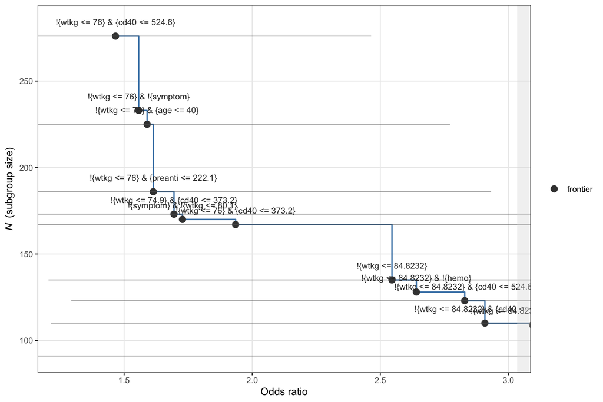

[output not shown]

```r
# Comprehensive summary with diagnostics

if(!is.null(fs$sg.harm)){
summaries <- summarize_bootstrap_results(
  sgharm = fs$sg.harm,
  boot_results = fs_bc,
  create_plots = TRUE,
  est.scale = "hr"
)
# Display bias-corrected estimates table
summaries$table

# Formatted gt table; selected subgroup is highlighted and marked with ★.
# Works uniformly for survival (HR) and GLM (OR, RR, IRR, RD, IRD, MD)
# outcomes -- effect column label and scale derived from fs$effect_measure.

# 1. Compute the CIs once (this is the expensive step, ~1-3 min on GBSG).
#    Parameters come from frontier_params in the Analysis Configuration.
ci_tab <- compute_frontier_cis(
  fs,
  n_splits = frontier_params$n_splits,
  seed     = frontier_params$seed
)

# 2. Plot, with split-derived CI bars overlaid; same intervals as the table.
p <- plot_pareto_frontier(
  fs,
  ci_table  = ci_tab,
  show_band = TRUE,
  xlim      = frontier_params$xlim
)
print(p)

# 3. Render the table. Pass the same ci_tab so the table and plot
#    show identical intervals.
pareto_frontier_table(
  fs,
  ci_table      = ci_tab,
  digits_effect = frontier_params$digits_effect,
  digits_pcons  = frontier_params$digits_pcons,
  digits_ci     = frontier_params$digits_ci
)


cat(explain_pareto_selection(fs, ci_table = ci_tab))
}
```

**Single simulated trial + FS analysis alt (click to expand)**

```r
df_sim <- simulate_from_glm_dgm(dgm_null, n = sim_n, seed = 44)
```

**Single simulated trial + FS analysis alt (click to expand)**

```r
frontier_params <- list(
  n_splits      = 1000L,
  seed          = 1L,
  xlim          = c(1.25, 3.0),
  digits_effect = 2L,
  digits_pcons  = 2L,
  digits_ci     = 2L
)

itt_fit <- glm(y_sim ~ treat_sim, family = "binomial", data = df_sim)
itt_OR <- exp(coef(itt_fit)["treat_sim"])
itt_event <- with(df_sim,mean(y_sim))

fs_params_single <- fs_params
fs_params_single$show_candidate_summary <- TRUE


fs_single <- do.call(forestsearch, c(
  list(df.analysis = df_sim, confounders.name = confounders),
  fs_params_single
))
```

```
[forestsearch] Subgroup Identification Configuration
  Outcome type:   binary
  Effect measure: OR (Odds Ratio)
  Scale:          log (ratio)

  Screening:      OR >= 1.25 (log: 0.2231)
  Consistency:    OR >= 1.00 (log: 0.0000)
  Consistency rate threshold: 90%

  Interpretation:
    Candidates: subgroup OR >= 1.25
    Splits:     each split OR >= 1.00
```

```
  Search Alignment Diagnostic
```

```
  Outcome:    y_sim (binary)
```

```
  Treatment:  treat_sim
```

```
  Measure:    Odds Ratio (OR) -- estimator sees Y as-is (no flip)
```

```
  ForestSearch searches for:
    Subgroups where treat_sim increases P(y_sim=1)
    (OR >= threshold on the ORIGINAL outcome scale)
```

```
  Thresholds:
    Screening: OR >= 1.250 in the candidate subgroup
    Consistency: OR >= 1.000 in each bootstrap split
```

```
  Variable screening:
```

```
    LASSO: LASSO screening: DISABLED
```

```
    GRF:   GRF sees 1-y_sim (flipped for causal_forest).
    Positive CATE = treatment REDUCES y_sim = treatment HELPS.
```

```
  No alignment concerns detected.
```

```
Forced confounders: ar_naive == 1, prior_6mo == 1
J-quantile cuts: cd40 (J=12), wtkg (J=12), preanti (J=12)
GRF subgroup: cd80 <= 524 & age <= 30 & wtkg <= 108.4
GRF cuts identified: 3
  Cuts: cd80 <= 524, age <= 30, wtkg <= 108.4104
Candidate factors: 54
 [1] "cd80 <= 524"       "age <= 30"         "wtkg <= 108.4104"
 [4] "cd40 <= 198"       "cd40 <= 231"       "cd40 <= 259"
 [7] "cd40 <= 280"       "cd40 <= 300"       "cd40 <= 324"
[10] "cd40 <= 346.4"     "cd40 <= 371"       "cd40 <= 389.9"
[13] "cd40 <= 421"       "cd40 <= 454"       "cd40 <= 500"
[16] "wtkg <= 57.2"      "wtkg <= 62.6"      "wtkg <= 66.3"
[19] "wtkg <= 68.9"      "wtkg <= 71"        "wtkg <= 73.3"
[22] "wtkg <= 76.2"      "wtkg <= 78.7"      "wtkg <= 81"
[25] "wtkg <= 84"        "wtkg <= 88.5"      "wtkg <= 96.2"
[28] "preanti <= 0"      "preanti <= 83"     "preanti <= 202"
[31] "preanti <= 396.9"  "preanti <= 600.9"  "preanti <= 782.8"
[34] "preanti <= 918"    "preanti <= 1106.8" "age <= 35.2"
[37] "age <= 34"         "age <= 40"         "karnof <= 95.3"
[40] "karnof <= 90"      "cd80 <= 966.4"     "cd80 <= 880.5"
[43] "cd80 <= 660"       "cd80 <= 1151.2"    "hemo"
[46] "homo"              "drugs"             "race"
[49] "gender"            "symptom"           "ar_naive"
[52] "prior_6mo"         "ar_naive == 1"     "prior_6mo == 1"
Number of possible configurations (<= maxk): maxk = 2 , # combinations = 5886
Per-arm events criteria: control >= 10, treatment >= 0
Sample size criteria: n >= 60
Subgroup search completed in 0.07 minutes

--- Filtering Summary ---
  Combinations evaluated: 5886
  Passed variance check: 5598
  Passed prevalence (>= 0.025 ): 5598
  Passed redundancy check: 5324
  Passed events counts (d0>= 10, d1>= 0): 4512
  Passed sample size (n>= 60 ): 4123
  GLM model fit successfully: 4123
  Passed effect threshold (OR >= 1.250): 22
-------------------------

```

[output cut: 46 more lines]

```
Batch 8 / 11 : candidates 15 - 16
Batch 9 / 11 : candidates 17 - 18
Batch 10 / 11 : candidates 19 - 20
Batch 11 / 11 : candidates 21 - 21
Evaluated 21 of 21 candidates (complete)
No subgroups found meeting consistency threshold

==============================================================================================================
CANDIDATE EVALUATION SUMMARY  (sg_focus = "hrMinSG", selection_rule = "neighborhood")
==============================================================================================================
Evaluated: 21   Passed: 0
No candidates met the consistency threshold.
==============================================================================================================
Seconds and minutes forestsearch overall = 24.896 0.4149
Consistency algorithm used: fixed
```

**Single simulated trial + FS analysis alt (click to expand)**

```r
if(!is.null(fs_single$sg.harm)){
fs_single_tabs <- sg_tables(fs_single, ndecimals = 3)
fs_single_tabs$sg10_out
fs_single_tabs$tab_estimates
}

t0 <- proc.time()
fs <- fs_single

if(!is.null(fs$sg.harm)){
fs_bc <- forestsearch_bootstrap_dofuture(
  fs.est = fs,
  nb_boots = 300,
  show_three = FALSE,
  details = FALSE,
  parallel_args = list(
    plan = "multisession",
    workers = n_workers,
    show_message = TRUE
  )
)

plan("sequential")
timings <- (proc.time() - t0)["elapsed"]

cat("\nBootstrap completed in",
    round(timings / 60, 1), "minutes\n")
}
# Comprehensive summary with diagnostics

if(!is.null(fs$sg.harm)){
summaries <- summarize_bootstrap_results(
  sgharm = fs$sg.harm,
  boot_results = fs_bc,
  create_plots = TRUE,
  est.scale = "hr"
)
# Display bias-corrected estimates table
summaries$table

# Formatted gt table; selected subgroup is highlighted and marked with ★.
# Works uniformly for survival (HR) and GLM (OR, RR, IRR, RD, IRD, MD)
# outcomes -- effect column label and scale derived from fs$effect_measure.

# 1. Compute the CIs once (this is the expensive step, ~1-3 min on GBSG).
#    Parameters come from frontier_params in the Analysis Configuration.
ci_tab <- compute_frontier_cis(
  fs,
  n_splits = frontier_params$n_splits,
  seed     = frontier_params$seed
)

# 2. Plot, with split-derived CI bars overlaid; same intervals as the table.
p <- plot_pareto_frontier(
  fs,
  ci_table  = ci_tab,
  show_band = TRUE,
  xlim      = frontier_params$xlim
)
print(p)

# 3. Render the table. Pass the same ci_tab so the table and plot
#    show identical intervals.
pareto_frontier_table(
  fs,
  ci_table      = ci_tab,
  digits_effect = frontier_params$digits_effect,
  digits_pcons  = frontier_params$digits_pcons,
  digits_ci     = frontier_params$digits_ci
)
cat(explain_pareto_selection(fs, ci_table = ci_tab))
}
```

# 4 Full Simulation Study

## 4.1 Parameter Lists

**Parallel plan setup (click to expand)**

```r
plan(multisession, workers = n_workers)
cat("Using", n_workers, "parallel workers\n")
```

```
Using 13 parallel workers
```

**Parallel plan setup (click to expand)**

```r
cat("fs_params and grf_params defined in setup chunk\n")
```

```
fs_params and grf_params defined in setup chunk
```

## 4.2 H1 Simulations (Calibrated HTE)

**H1 simulation loop (click to expand)**

```r
cat("Running", nsims_alt, "simulations under H1...\n")
t0 <- proc.time()[3]

results_alt_raw <- foreach(
  sim = seq_len(nsims_alt),
  .errorhandling = "pass",
  .options.future = list(
    packages = c("forestsearch", "survival", "data.table", "future"),
    seed = TRUE
  )
) %dofuture% {
  future::plan("sequential")
  run_simulation_analysis(
    sim_id           = sim,
    dgm              = dgm_calibrated,
    n_sample         = sim_n,
    confounders_base = confounders,
    run_fs           = TRUE,
    run_fs_grf       = FALSE,
    run_grf          = TRUE,
    fs_params        = fs_params,
    grf_params       = grf_params,
    keep             = diag_keep,
    keep_first_n     = diag_keep_first_n,
    verbose          = FALSE
  )
}

t_alt <- proc.time()[3] - t0
results_alt <- collect_results(results_alt_raw, "H1 alt",
                               keep_diagnostics = diag_keep_first_n > 0L)
n_failed_alt <- attr(results_alt, "n_failed")

cat(sprintf("Completed in %.1f min (%d rows, %d failed)\n",
    t_alt / 60, nrow(results_alt), n_failed_alt))
```

## 4.3 H0 Simulations (Null — Homogeneous Effect)

**H0 simulation loop (click to expand)**

```r
cat("Running", nsims_null, "simulations under H0...\n")
t0 <- proc.time()[3]

results_null_raw <- foreach(
  sim = seq_len(nsims_null),
  .errorhandling = "pass",
  .options.future = list(
    packages = c("forestsearch", "survival", "data.table", "future"),
    seed = TRUE
  )
) %dofuture% {
  future::plan("sequential")
  run_simulation_analysis(
    sim_id           = sim,
    dgm              = dgm_null,
    n_sample         = sim_n,
    confounders_base = confounders,
    run_fs           = TRUE,
    run_fs_grf       = FALSE,
    run_grf          = TRUE,
    fs_params        = fs_params,
    grf_params       = grf_params,
    verbose          = FALSE
  )
}

t_null <- proc.time()[3] - t0
results_null <- collect_results(results_null_raw, "H0 null")
n_failed_null <- attr(results_null, "n_failed")

cat(sprintf("Completed in %.1f min (%d rows, %d failed)\n",
    t_null / 60, nrow(results_null), n_failed_null))
```

## 4.4 Save Bundle (full mode only)

**Bundle assembly + saveRDS (click to expand)**

```r
bundle <- list(
  meta = list(
    config_id         = CONFIG_ID,
    timestamp         = Sys.time(),
    n_alt             = nsims_alt,
    n_null            = nsims_null,
    sim_n             = sim_n,
    confounders       = confounders,
    fs_params         = fs_params,
    grf_params        = grf_params,
    diag_keep         = diag_keep,
    diag_keep_first_n = diag_keep_first_n,
    t_alt_sec         = unname(t_alt),
    t_null_sec        = unname(t_null),
    n_failed_alt      = attr(results_alt,  "n_failed"),
    n_failed_null     = attr(results_null, "n_failed"),
    package_version   = as.character(utils::packageVersion("forestsearch")),
    sessionInfo       = utils::sessionInfo()
  ),
  dgm = list(
    calibrated = dgm_calibrated,
    null       = dgm_null
  ),
  results = list(
    alt  = results_alt,
    null = results_null
  )
)

saveRDS(bundle, BUNDLE_PATH)
cat(sprintf("Bundle saved to: %s\n", BUNDLE_PATH))
```

```
Bundle saved to: actg175_binary_m1_harm_fs7_effMinSG_neighborhood_n700_sims1000.rds
```

**Bundle assembly + saveRDS (click to expand)**

```r
cat(sprintf("  H1: %.1f min, %d rows, %d failed\n",
            t_alt  / 60, nrow(results_alt),  n_failed_alt))
```

```
  H1: 101.2 min, 2000 rows, 0 failed
```

**Bundle assembly + saveRDS (click to expand)**

```r
cat(sprintf("  H0: %.1f min, %d rows, %d failed\n",
            t_null / 60, nrow(results_null), n_failed_null))
```

```
  H0: 87.6 min, 2000 rows, 0 failed
```

## 4.5 Mode Handoff

**Bundle import or sim-result handoff (click to expand)**

```r
if (sim_mode == "import") {
  bundle <- readRDS(BUNDLE_PATH)

  # Override the freshly-built DGMs with the bundle's versions so that
  # downstream OC tables match the simulation results they describe.
  dgm_calibrated <- bundle$dgm$calibrated
  dgm_null       <- bundle$dgm$null

  results_alt    <- bundle$results$alt
  results_null   <- bundle$results$null
  t_alt          <- bundle$meta$t_alt_sec
  t_null         <- bundle$meta$t_null_sec
  nsims_alt      <- bundle$meta$n_alt
  nsims_null     <- bundle$meta$n_null
  n_failed_alt   <- bundle$meta$n_failed_alt
  n_failed_null  <- bundle$meta$n_failed_null

  cat(sprintf("Imported bundle: %s\n", BUNDLE_PATH))
  cat(sprintf("  config_id : %s\n", bundle$meta$config_id))
  cat(sprintf("  timestamp : %s\n", format(bundle$meta$timestamp)))
  cat(sprintf("  n_alt     : %d (failed: %d)\n",
              nsims_alt, n_failed_alt))
  cat(sprintf("  n_null    : %d (failed: %d)\n",
              nsims_null, n_failed_null))
  if (!is.null(bundle$meta$package_version)) {
    cat(sprintf("  forestsearch %s\n", bundle$meta$package_version))
  }
  if (!is.null(bundle$meta$config_id) &&
      bundle$meta$config_id != CONFIG_ID) {
    warning(sprintf(
      "Bundle config_id ('%s') does not match this article ('%s').",
      bundle$meta$config_id, CONFIG_ID
    ), call. = FALSE)
  }
} else {
  cat(sprintf("Inline simulation complete (%s mode).\n", sim_mode))
}
```

```
Inline simulation complete (full mode).
```

# 5 Results

## 5.1 Metrics Glossary

Classification metrics follow the definitions in León et al. (2024, Section 3).

### 5.1.1 Detection

**Found** ($\text{any}(Q)$): proportion of simulations where the method identifies *any* harm subgroup ($\texttt{any.H} = 1$).

- **Under H1** (alternative): $Q$ exists with a differential treatment effect. $\text{any}(Q)$ is **detection power**.
- **Under H0** (null): $Q = \emptyset$ and $Q^c$ is the ITT population. $\text{any}(Q)$ is the **false positive rate (FPR)** for falsely declaring that a harm subgroup exists.

### 5.1.2 Classification Under H1

$$\text{sens}(\hat{Q}) = \frac{\#\{i \in \hat{Q} \cap Q\}}{\#\{i \in Q\}},
\quad
\text{ppv}(\hat{Q}) = \frac{\#\{i \in \hat{Q} \cap Q\}}{\#\{i \in \hat{Q}\}},$$

with analogous measures for the complement $\hat{Q}^c$.

The operating-characteristics tables report these as:

| Table column | León et al. notation | Interpretation |
| --- | --- | --- |
| **Sen** | $\text{sens}(\hat{Q})$ | Fraction of true $Q$ captured by $\hat{Q}$ |
| **Spec** | $\text{sens}(\hat{Q}^c)$ | Fraction of true $Q^c$ correctly in $\hat{Q}^c$ |
| **PPV** | $\text{ppv}(\hat{Q})$ | Fraction of $\hat{Q}$ truly in $Q$ |
| **NPV** | $\text{ppv}(\hat{Q}^c)$ | Fraction of $\hat{Q}^c$ truly in $Q^c$ |

Classification metrics are averaged across **all** simulations (León et al. 2024, Table 1). When no subgroup is detected ($\hat{Q} = \emptyset$), the simulation contributes $\text{sens}(\hat{Q}) = 0$ and $\text{ppv}(\hat{Q}) = 0$ (since no member of $Q$ is captured and no subjects are assigned to $\hat{Q}$). This convention is implemented at the source in `run_simulation_analysis()`, matching the original `fs.estimates.out()` function used in León et al. (2024).

**NoteClassification metrics with discovered cuts**

### 5.1.3 Classification Under H0

Under the null, $Q = \emptyset$ — no subgroup with a differential treatment effect exists. The complement $Q^c$ is the entire ITT population. Per León et al. (2024, Section 3), $\text{sens}(\hat{Q})$ is **undefined** (shown as “—” in the table) and $\text{ppv}(\hat{Q}) \equiv 0$. For the complement, $\text{sens}(\hat{Q}^c) = |\hat{Q}^c|/N$ and $\text{ppv}(\hat{Q}^c) = 1$ since $Q^c$ = ITT.

The only operationally meaningful metric under H0 is the **detection rate (FPR)**.

### 5.1.4 Effect Estimates

All effect estimates are on the adverse scale: OR $> 1$ = treatment (ZDV+ddI) increases the adverse outcome (non-improvement) = **harm**. No inversion or treatment switching is applied.

# 6 Operating Characteristics

## 6.1 H1: Detection + Classification

```r
format_oc_results(
  results_alt,
  metrics   = c("detection", "classification", "subgroup_size"),
  digits    = 2,
  digits_hr = 2,
  title     = "ACTG175 Binary: Harm Subgroup Identification",
  dgm = dgm_calibrated,
  subgroup_notation = sg_notation
)
```

ACTG175 Binary: Harm Subgroup Identification

1000 sims, OR(H) = 2.00, OR(Hᶜ) = 0.66

| Method | Sims | Found | Classification Sen | Classification Spec | Classification PPV | Classification NPV | Identified Harm Subgroup Size avg\|Ĥ\| | Identified Harm Subgroup Size min\|Ĥ\| | Identified Harm Subgroup Size max\|Ĥ\| |
| --- | --- | --- | --- | --- | --- | --- | --- | --- | --- |
| FS | 1000 | 0.92 | 0.42 | 0.93 | 0.46 | 0.94 | 73 | 61 | 241 |
| GRF | 1000 | 0.98 | 0.59 | 0.77 | 0.25 | 0.94 | 193 | 60 | 484 |

### 6.1.1 True Subgroup Sizes Across Replicates

```r
# One row per replicate-method combination, but sizeH_true is identical
# across method rows within the same sim.  Deduplicate on sim.
truth_by_sim <- unique(results_alt[, c("sim", "sizeH_true", "sizeHc_true",
                                        "propH_true", "propHc_true")])

callout_Q <- sprintf(
  "|Q|:  mean = %.1f (SD %.2f),  range = [%d, %d],  prop = %.1f%%",
  mean(truth_by_sim$sizeH_true),
  sd(truth_by_sim$sizeH_true),
  min(truth_by_sim$sizeH_true),
  max(truth_by_sim$sizeH_true),
  100 * mean(truth_by_sim$propH_true))

callout_Qc <- sprintf(
  "|Qc|: mean = %.1f (SD %.2f),  range = [%d, %d],  prop = %.1f%%",
  mean(truth_by_sim$sizeHc_true),
  sd(truth_by_sim$sizeHc_true),
  min(truth_by_sim$sizeHc_true),
  max(truth_by_sim$sizeHc_true),
  100 * mean(truth_by_sim$propHc_true))

cat(sprintf("True subgroup sizes across %d H1 replicates (N = %d each):\n",
            nrow(truth_by_sim), sim_n))
```

```
True subgroup sizes across 1000 H1 replicates (N = 700 each):
```

```r
cat("  ", callout_Q,  "\n")
```

```
   |Q|:  mean = 77.3 (SD 8.31),  range = [54, 104],  prop = 11.0%
```

```r
cat("  ", callout_Qc, "\n")
```

```
   |Qc|: mean = 622.7 (SD 8.31),  range = [596, 646],  prop = 89.0%
```

**NoteReference sizes for the estimation tables below**

- **|Q| (true harm subgroup)**: mean 77.3 per trial (SD 8.31, range 54–104, average proportion 11.0%).
- **|Qc| (complement)**: mean 622.7 per trial (SD 8.31, range 596–646, average proportion 89.0%).

Compare to $\widehat{|H|}$ (the FS-identified subgroup size) reported in the row-group labels of the estimation tables below. A ratio $\widehat{|H|} \big/ \overline{|Q|} \approx 1$ indicates the method is recovering a subgroup close to the true size; values much smaller suggest FS is identifying a strict subset of $Q$; values larger suggest FS is absorbing some $Q^c$ subjects into $\hat H$.

## 6.2 H1: Estimation Tables

```r
build_estimation_table(
  results         = results_alt,
  dgm             = dgm_calibrated,
  analysis_method = "FS",
  subgroup_notation = sg_notation,
  title           = "FS: Effect Estimates Under H1"
)
```

FS: Effect Estimates Under H1

FS: 919/1000 (92%) estimable

|  | Avg | SD | Min | Max | b‡ (%) | b† (%) |
| --- | --- | --- | --- | --- | --- | --- |
| Ĥ: 919 estimable, avg \|Ĥ\| = 73, θ†(H) = 2, θ‡(H) = 2.11 |  |  |  |  |  |  |
| θ̂(Ĥ) | 3.59 | 1.41 | 1.62 | 17.00 | 70.41 | 79.96 |
| âhr(Ĥ) | 1.21 | 0.47 | 0.64 | 2.04 | NA | -39.24 |
| θ‡(Ĥ) | 1.43 | 0.50 | 0.63 | 2.11 | NA | -32.36 |
| Ĥᶜ: avg \|Ĥᶜ\| = 627, θ†(Hᶜ) = 0.66, θ‡(Hᶜ) = 0.63 |  |  |  |  |  |  |
| θ̂(Ĥᶜ) | 0.65 | 0.10 | 0.40 | 1.09 | 2.01 | -1.83 |
| âhr(Ĥᶜ) | 0.71 | 0.03 | 0.66 | 0.80 | NA | 8.37 |
| θ‡(Ĥᶜ) | 0.77 | 0.09 | 0.63 | 0.99 | NA | 21.91 |

θ̂(Ĥ) = plugin OR estimate in identified subgroup; θ̂*(Ĥ) = bootstrap bias-corrected; b† = bias relative to true OR θ† (causal truth); θ‡(Ĥ) = controlled direct effect in identified subgroup; b‡ = bias relative to CDE θ‡

```r
build_estimation_table(
  results         = results_alt,
  dgm             = dgm_calibrated,
  analysis_method = "GRF",
  subgroup_notation = sg_notation,
  title           = "GRF: Effect Estimates Under H1"
)
```

GRF: Effect Estimates Under H1

GRF: 985/1000 (98%) estimable

|  | Avg | SD | Min | Max | b‡ (%) | b† (%) |
| --- | --- | --- | --- | --- | --- | --- |
| Ĥ: 985 estimable, avg \|Ĥ\| = 193, θ†(H) = 2, θ‡(H) = 2.11 |  |  |  |  |  |  |
| θ̂(Ĥ) | 2.58 | 0.98 | 1.40 | 9.60 | 22.50 | 29.37 |
| âhr(Ĥ) | 0.89 | 0.14 | 0.65 | 1.55 | NA | -55.59 |
| θ‡(Ĥ) | 1.11 | 0.26 | 0.63 | 1.94 | NA | -47.38 |
| Ĥᶜ: avg \|Ĥᶜ\| = 507, θ†(Hᶜ) = 0.66, θ‡(Hᶜ) = 0.63 |  |  |  |  |  |  |
| θ̂(Ĥᶜ) | 0.48 | 0.09 | 0.23 | 0.85 | -23.92 | -26.78 |
| âhr(Ĥᶜ) | 0.71 | 0.04 | 0.65 | 0.85 | NA | 7.15 |
| θ‡(Ĥᶜ) | 0.76 | 0.09 | 0.63 | 1.02 | NA | 19.80 |

θ̂(Ĥ) = plugin OR estimate in identified subgroup; θ̂*(Ĥ) = bootstrap bias-corrected; b† = bias relative to true OR θ† (causal truth); θ‡(Ĥ) = controlled direct effect in identified subgroup; b‡ = bias relative to CDE θ‡

## 6.3 H1: Classification Tables

```r
scenario_alt <- list(
  H1 = list(
    results    = results_alt,
    dgm        = dgm_calibrated,
    hypothesis = "alt",
    n_sample   = sim_n,
    label      = "ACTG175"
  )
)

build_classification_table(
  scenario_alt,
  analyses          = "FS",
  subgroup_notation = sg_notation,
  title             = "FS: Classification Under H1"
)
```

FS: Classification Under H1

|  | FS |
| --- | --- |
| ACTG175 Alt: N=700, p_H=11%, theta(H)=2, theta(Hc)=0.66, theta(ITT)=0.75 |  |
| any(H) | 0.92 |
| sens(H) | 0.42 |
| sens(Hc) | 0.93 |
| ppv(H) | 0.46 |
| ppv(Hc) | 0.94 |
| avg\|H\| | 73.00 |

```r
build_classification_table(
  scenario_alt,
  analyses          = "GRF",
  subgroup_notation = sg_notation,
  title             = "GRF: Classification Under H1"
)
```

GRF: Classification Under H1

|  | GRF |
| --- | --- |
| ACTG175 Alt: N=700, p_H=11%, theta(H)=2, theta(Hc)=0.66, theta(ITT)=0.75 |  |
| any(H) | 0.98 |
| sens(H) | 0.59 |
| sens(Hc) | 0.77 |
| ppv(H) | 0.25 |
| ppv(Hc) | 0.94 |
| avg\|H\| | 193.00 |

## 6.4 H1: Subgroup Distribution

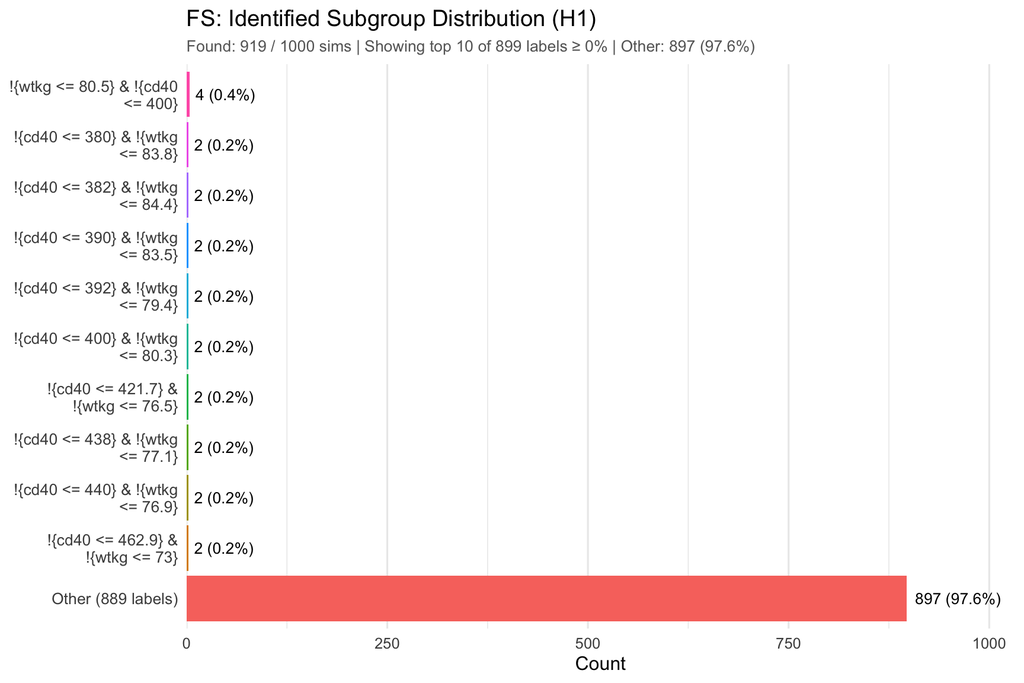

```r
plot_sg_distribution(
  results_alt[results_alt$analysis == "FS", ],
  any_col   = "any.H",
  label_col = "sg.def",
  min_pct   = sgdist_min_pct_alt,
  top_k     = sgdist_top_k,
  title     = "FS: Identified Subgroup Distribution (H1)"
)
```

## 6.5 H1: OR Distribution

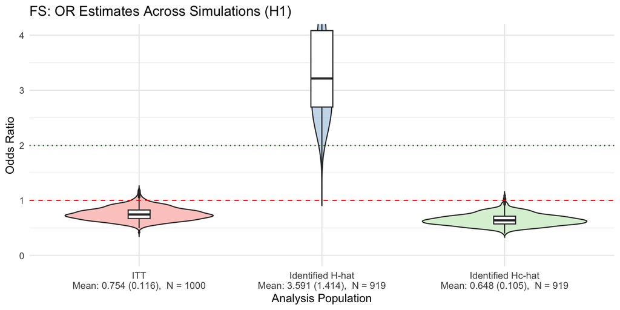

```r
or_Q_true <- dgm_calibrated$hazard_ratios$harm_subgroup

plot_effect_distribution(
  results           = results_alt,
  analysis_method   = "FS",
  effect_measure    = "OR",
  subgroup_notation = sg_notation,
  reference_effect  = or_Q_true,
  ylim              = ordist_ylim,
  title             = "FS: OR Estimates Across Simulations (H1)"
)
```

## 6.6 H0: Type I Error

```r
format_oc_results(
  results_null,
  dgm = dgm_null,
  metrics   = c("detection", "classification"),
  digits    = 2,
  title     = "ACTG175 Binary: Type I Error (Null)",
   subgroup_notation = sg_notation
)
```

ACTG175 Binary: Type I Error (Null)

1000 sims, OR(H) = NA, OR(Hᶜ) = 0.66

| Method | Sims | Found | Classification Sen | Classification Spec | Classification PPV | Classification NPV |
| --- | --- | --- | --- | --- | --- | --- |
| FS | 1000 | 0.67 | - | 0.92 | 0.00 | 1.00 |
| GRF | 1000 | 0.95 | - | 0.79 | 0.00 | 1.00 |

## 6.7 H0: Estimation Tables

```r
build_estimation_table(
  results         = results_null,
  dgm             = dgm_null,
  analysis_method = "FS",
  subgroup_notation = sg_notation,
  title           = "FS: Effect Estimates Under H0"
)
```

FS: Effect Estimates Under H0

FS: 666/1000 (67%) estimable

|  | Avg | SD | Min | Max | b‡ (%) | b† (%) |
| --- | --- | --- | --- | --- | --- | --- |
| Ĥ: 666 estimable, avg \|Ĥ\| = 83, θ†(H) = 0.66, θ‡(H) = 0.63 |  |  |  |  |  |  |
| θ̂(Ĥ) | 2.75 | 0.74 | 1.53 | 8.82 | 332.92 | 315.88 |
| âhr(Ĥ) | 0.66 | 0.01 | 0.64 | 0.68 | NA | -0.66 |
| θ‡(Ĥ) | 0.63 | 0.00 | 0.63 | 0.63 | NA | 0.00 |
| Ĥᶜ: avg \|Ĥᶜ\| = 617, θ†(Hᶜ) = 0.66, θ‡(Hᶜ) = 0.63 |  |  |  |  |  |  |
| θ̂(Ĥᶜ) | 0.59 | 0.10 | 0.31 | 0.95 | -7.79 | -11.41 |
| âhr(Ĥᶜ) | 0.66 | 0.00 | 0.65 | 0.67 | NA | -0.13 |
| θ‡(Ĥᶜ) | 0.63 | 0.00 | 0.63 | 0.63 | NA | 0.00 |

θ̂(Ĥ) = plugin OR estimate in identified subgroup; θ̂*(Ĥ) = bootstrap bias-corrected; b† = bias relative to true OR θ† (causal truth); θ‡(Ĥ) = controlled direct effect in identified subgroup; b‡ = bias relative to CDE θ‡

```r
build_estimation_table(
  results         = results_null,
  dgm             = dgm_null,
  analysis_method = "GRF",
  subgroup_notation = sg_notation,
  title           = "GRF: Effect Estimates Under H0"
)
```

GRF: Effect Estimates Under H0

GRF: 950/1000 (95%) estimable

|  | Avg | SD | Min | Max | b‡ (%) | b† (%) |
| --- | --- | --- | --- | --- | --- | --- |
| Ĥ: 950 estimable, avg \|Ĥ\| = 157, θ†(H) = 0.66, θ‡(H) = 0.63 |  |  |  |  |  |  |
| θ̂(Ĥ) | 2.66 | 1.07 | 1.42 | 9.74 | 319.45 | 302.95 |
| âhr(Ĥ) | 0.66 | 0.01 | 0.64 | 0.71 | NA | 0.07 |
| θ‡(Ĥ) | 0.63 | 0.00 | 0.63 | 0.63 | NA | 0.00 |
| Ĥᶜ: avg \|Ĥᶜ\| = 543, θ†(Hᶜ) = 0.66, θ‡(Hᶜ) = 0.63 |  |  |  |  |  |  |
| θ̂(Ĥᶜ) | 0.46 | 0.07 | 0.23 | 0.83 | -27.53 | -30.38 |
| âhr(Ĥᶜ) | 0.66 | 0.00 | 0.65 | 0.67 | NA | -0.27 |
| θ‡(Ĥᶜ) | 0.63 | 0.00 | 0.63 | 0.63 | NA | 0.00 |

θ̂(Ĥ) = plugin OR estimate in identified subgroup; θ̂*(Ĥ) = bootstrap bias-corrected; b† = bias relative to true OR θ† (causal truth); θ‡(Ĥ) = controlled direct effect in identified subgroup; b‡ = bias relative to CDE θ‡

## 6.8 H0: Subgroup Distribution

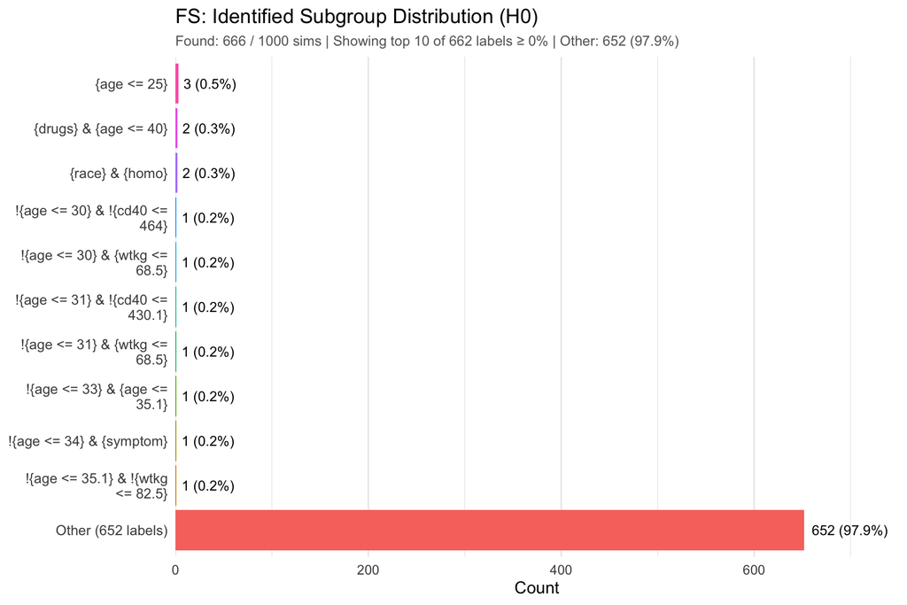

```r
plot_sg_distribution(
  results_null[results_null$analysis == "FS", ],
  any_col   = "any.H",
  label_col = "sg.def",
  min_pct   = sgdist_min_pct_null,
  top_k     = sgdist_top_k,
  title     = "FS: Identified Subgroup Distribution (H0)"
)
```

# 7 Timing

```r
cat(sprintf("Mode: %s\n", sim_mode))
```

```
Mode: full
```

```r
cat(sprintf("H1: %.1f min (%d sims)\n", t_alt / 60, nsims_alt))
```

```
H1: 101.2 min (1000 sims)
```

```r
cat(sprintf("H0: %.1f min (%d sims)\n", t_null / 60, nsims_null))
```

```
H0: 87.6 min (1000 sims)
```

```r
plan(sequential)
```